# Project: Predict Bike Sharing Demand with AutoGluon

This notebook is a template with each step that you need to complete for the project.

Please fill in your code where there are explicit `?` markers in the notebook. You are welcome to add more cells and code as you see fit.

Once you have completed all the code implementations, please export your notebook as a HTML file so the reviews can view your code. Make sure you have all outputs correctly outputted.

`File-> Export Notebook As... -> Export Notebook as HTML`

There is a writeup to complete as well after all code implememtation is done. Please answer all questions and attach the necessary tables and charts. You can complete the writeup in either markdown or PDF.

Completing the code template and writeup template will cover all of the rubric points for this project.

The rubric contains "Stand Out Suggestions" for enhancing the project beyond the minimum requirements. The stand out suggestions are optional. If you decide to pursue the "stand out suggestions", you can include the code in this notebook and also discuss the results in the writeup file.

## Step 1: Create an account with Kaggle

### Create Kaggle Account and download API key

Below is example of steps to get the API username and key. Each student will have their own username and key.

1. Open account settings.

2. Scroll down to API and click Create New API Token.

3. Open up `kaggle.json` and use the username and key.


## Step 2: Download the Kaggle dataset using the kaggle python library

### Open up Sagemaker Studio and use starter template

1. Notebook should be using a `ml.t3.medium` instance (2 vCPU + 4 GiB)
2. Notebook should be using kernal: `Python 3 (MXNet 1.8 Python 3.7 CPU Optimized)`

### Install packages

```python
!pip install -U pip
!pip install -U setuptools wheel

!pip install pandas
!pip install kaggle
!pip install -U "mxnet<2.0.0" bokeh==2.0.1
!pip install autogluon --no-cache-dir
# Without --no-cache-dir, smaller aws instances may have trouble installing
```

### Setup Kaggle API Key

```python
## Linux environment
# create the .kaggle directory and an empty kaggle.json file
!mkdir -p /root/.kaggle
!touch /root/.kaggle/kaggle.json
!chmod 600 /root/.kaggle/kaggle.json
```

```python
## Linux environment
# Fill in your user name and key from creating the kaggle account and API token file
import json
kaggle_username = "FILL_IN_USERNAME"
kaggle_key = "FILL_IN_KEY"

# Save API token the kaggle.json file
with open("/root/.kaggle/kaggle.json", "w") as f:
    f.write(json.dumps({"username": kaggle_username, "key": kaggle_key}))
```

```python
## Windows environment
import os

# Create the .kaggle directory
kaggle_dir = os.path.expanduser("~/.kaggle")
os.makedirs(kaggle_dir, exist_ok=True)

# Create an empty kaggle.json file
kaggle_json = os.path.join(kaggle_dir, "kaggle.json")
open(kaggle_json, 'a').close()

# Set permissions for the file
os.chmod(kaggle_json, 0o600)
```

```python
## Windows environment
import os
import json

# Fill in your user name and key from creating the kaggle account and API token file
kaggle_username = "FILL_IN_USERNAME"
kaggle_key = "FILL_IN_KEY"

# Define the path for the kaggle.json file
kaggle_dir = os.path.expanduser("~/.kaggle")
kaggle_json = os.path.join(kaggle_dir, "kaggle.json")

# Create the .kaggle directory if it doesn't exist
os.makedirs(kaggle_dir, exist_ok=True)

# Save the API token to the kaggle.json file
with open(kaggle_json, "w") as f:
    json.dump({"username": kaggle_username, "key": kaggle_key}, f)
```

### Download and explore dataset

### Go to the bike sharing demand competition and agree to the terms

```python
# Download the dataset, it will be in a .zip file so you'll need to unzip it as well.
!kaggle competitions download -c bike-sharing-demand
# If you already downloaded it you can use the -o command to overwrite the file
!unzip -o bike-sharing-demand.zip
!rm bike-sharing-demand.zip
!mkdir data && mv *csv ./data
```

```
Downloading bike-sharing-demand.zip to D:\GitHub\udacity-aws-ai-ml\1-intro-ml\project
```

```
Archive:  bike-sharing-demand.zip
  inflating: sampleSubmission.csv
  inflating: test.csv
  inflating: train.csv
```

```python
import pandas as pd
from autogluon.tabular import TabularPredictor
```

```python
# Create the train dataset in pandas by reading the csv
# Set the parsing of the datetime column so you can use some of the `dt` features in pandas later
train = pd.read_csv("data/train.csv", parse_dates=['datetime'])
train.head()
```

|  | datetime | season | holiday | workingday | weather | temp | atemp | humidity | windspeed | casual | registered | count |
| --- | --- | --- | --- | --- | --- | --- | --- | --- | --- | --- | --- | --- |
| 0 | 2011-01-01 00:00:00 | 1 | 0 | 0 | 1 | 9.84 | 14.395 | 81 | 0.0 | 3 | 13 | 16 |
| 1 | 2011-01-01 01:00:00 | 1 | 0 | 0 | 1 | 9.02 | 13.635 | 80 | 0.0 | 8 | 32 | 40 |
| 2 | 2011-01-01 02:00:00 | 1 | 0 | 0 | 1 | 9.02 | 13.635 | 80 | 0.0 | 5 | 27 | 32 |
| 3 | 2011-01-01 03:00:00 | 1 | 0 | 0 | 1 | 9.84 | 14.395 | 75 | 0.0 | 3 | 10 | 13 |
| 4 | 2011-01-01 04:00:00 | 1 | 0 | 0 | 1 | 9.84 | 14.395 | 75 | 0.0 | 0 | 1 | 1 |

```python
train.info()
```

```
<class 'pandas.core.frame.DataFrame'>
RangeIndex: 10886 entries, 0 to 10885
Data columns (total 12 columns):
 #   Column      Non-Null Count  Dtype
---  ------      --------------  -----
 0   datetime    10886 non-null  datetime64[ns]
 1   season      10886 non-null  int64
 2   holiday     10886 non-null  int64
 3   workingday  10886 non-null  int64
 4   weather     10886 non-null  int64
 5   temp        10886 non-null  float64
 6   atemp       10886 non-null  float64
 7   humidity    10886 non-null  int64
 8   windspeed   10886 non-null  float64
 9   casual      10886 non-null  int64
 10  registered  10886 non-null  int64
 11  count       10886 non-null  int64
dtypes: datetime64[ns](1), float64(3), int64(8)
memory usage: 1020.7 KB
```

```python
# Simple output of the train dataset to view some of the min/max/varition of the dataset features.
train.describe()
```

|  | datetime | season | holiday | workingday | weather | temp | atemp | humidity | windspeed | casual | registered | count |
| --- | --- | --- | --- | --- | --- | --- | --- | --- | --- | --- | --- | --- |
| count | 10886 | 10886.000000 | 10886.000000 | 10886.000000 | 10886.000000 | 10886.00000 | 10886.000000 | 10886.000000 | 10886.000000 | 10886.000000 | 10886.000000 | 10886.000000 |
| mean | 2011-12-27 05:56:22.399411968 | 2.506614 | 0.028569 | 0.680875 | 1.418427 | 20.23086 | 23.655084 | 61.886460 | 12.799395 | 36.021955 | 155.552177 | 191.574132 |
| min | 2011-01-01 00:00:00 | 1.000000 | 0.000000 | 0.000000 | 1.000000 | 0.82000 | 0.760000 | 0.000000 | 0.000000 | 0.000000 | 0.000000 | 1.000000 |
| 25% | 2011-07-02 07:15:00 | 2.000000 | 0.000000 | 0.000000 | 1.000000 | 13.94000 | 16.665000 | 47.000000 | 7.001500 | 4.000000 | 36.000000 | 42.000000 |
| 50% | 2012-01-01 20:30:00 | 3.000000 | 0.000000 | 1.000000 | 1.000000 | 20.50000 | 24.240000 | 62.000000 | 12.998000 | 17.000000 | 118.000000 | 145.000000 |
| 75% | 2012-07-01 12:45:00 | 4.000000 | 0.000000 | 1.000000 | 2.000000 | 26.24000 | 31.060000 | 77.000000 | 16.997900 | 49.000000 | 222.000000 | 284.000000 |
| max | 2012-12-19 23:00:00 | 4.000000 | 1.000000 | 1.000000 | 4.000000 | 41.00000 | 45.455000 | 100.000000 | 56.996900 | 367.000000 | 886.000000 | 977.000000 |
| std | NaN | 1.116174 | 0.166599 | 0.466159 | 0.633839 | 7.79159 | 8.474601 | 19.245033 | 8.164537 | 49.960477 | 151.039033 | 181.144454 |

```python
# Create the test pandas dataframe in pandas by reading the csv, remember to parse the datetime!
test = pd.read_csv("data/test.csv", parse_dates=['datetime'])
test.head()
```

|  | datetime | season | holiday | workingday | weather | temp | atemp | humidity | windspeed |
| --- | --- | --- | --- | --- | --- | --- | --- | --- | --- |
| 0 | 2011-01-20 00:00:00 | 1 | 0 | 1 | 1 | 10.66 | 11.365 | 56 | 26.0027 |
| 1 | 2011-01-20 01:00:00 | 1 | 0 | 1 | 1 | 10.66 | 13.635 | 56 | 0.0000 |
| 2 | 2011-01-20 02:00:00 | 1 | 0 | 1 | 1 | 10.66 | 13.635 | 56 | 0.0000 |
| 3 | 2011-01-20 03:00:00 | 1 | 0 | 1 | 1 | 10.66 | 12.880 | 56 | 11.0014 |
| 4 | 2011-01-20 04:00:00 | 1 | 0 | 1 | 1 | 10.66 | 12.880 | 56 | 11.0014 |

```python
# Same thing as train and test dataset
submission = pd.read_csv("data/sampleSubmission.csv", parse_dates=['datetime'])
submission.head()
```

|  | datetime | count |
| --- | --- | --- |
| 0 | 2011-01-20 00:00:00 | 0 |
| 1 | 2011-01-20 01:00:00 | 0 |
| 2 | 2011-01-20 02:00:00 | 0 |
| 3 | 2011-01-20 03:00:00 | 0 |
| 4 | 2011-01-20 04:00:00 | 0 |

## Step 3: Train a model using AutoGluon’s Tabular Prediction

Requirements:

- We are predicting `count`, so it is the label we are setting.
- Ignore `casual` and `registered` columns as they are also not present in the test dataset.
- Use the `root_mean_squared_error` as the metric to use for evaluation.
- Set a time limit of 10 minutes (600 seconds).
- Use the preset `best_quality` to focus on creating the best model.

```python
predictor = TabularPredictor(
    label='count',
    problem_type='regression',
    eval_metric='root_mean_squared_error'
).fit(
    train_data=train.drop(columns=['casual', 'registered']),
    time_limit=600,
    presets='best_quality'
)
```

```
No path specified. Models will be saved in: "AutogluonModels\ag-20230602_100206\"
Presets specified: ['best_quality']
Stack configuration (auto_stack=True): num_stack_levels=1, num_bag_folds=8, num_bag_sets=20
Beginning AutoGluon training ... Time limit = 600s
AutoGluon will save models to "AutogluonModels\ag-20230602_100206\"
AutoGluon Version:  0.7.0
Python Version:     3.9.16
Operating System:   Windows
Platform Machine:   AMD64
Platform Version:   10.0.22621
Train Data Rows:    10886
Train Data Columns: 9
Label Column: count
Preprocessing data ...
Using Feature Generators to preprocess the data ...
Fitting AutoMLPipelineFeatureGenerator...
	Available Memory:                    2088.11 MB
	Train Data (Original)  Memory Usage: 0.78 MB (0.0% of available memory)
	Inferring data type of each feature based on column values. Set feature_metadata_in to manually specify special dtypes of the features.
	Stage 1 Generators:
		Fitting AsTypeFeatureGenerator...
			Note: Converting 2 features to boolean dtype as they only contain 2 unique values.
	Stage 2 Generators:
		Fitting FillNaFeatureGenerator...
	Stage 3 Generators:
		Fitting IdentityFeatureGenerator...
		Fitting DatetimeFeatureGenerator...
	Stage 4 Generators:
		Fitting DropUniqueFeatureGenerator...
	Types of features in original data (raw dtype, special dtypes):
		('datetime', []) : 1 | ['datetime']
		('float', [])    : 3 | ['temp', 'atemp', 'windspeed']
		('int', [])      : 5 | ['season', 'holiday', 'workingday', 'weather', 'humidity']
	Types of features in processed data (raw dtype, special dtypes):
		('float', [])                : 3 | ['temp', 'atemp', 'windspeed']
		('int', [])                  : 3 | ['season', 'weather', 'humidity']
		('int', ['bool'])            : 2 | ['holiday', 'workingday']
		('int', ['datetime_as_int']) : 5 | ['datetime', 'datetime.year', 'datetime.month', 'datetime.day', 'datetime.dayofweek']
	0.1s = Fit runtime
	9 features in original data used to generate 13 features in processed data.
```

[output cut: 85 more lines]

```
	-54.1247	 = Validation score   (-root_mean_squared_error)
	5.44s	 = Training   runtime
	0.61s	 = Validation runtime
Fitting model: NeuralNetFastAI_BAG_L2 ... Training model for up to 25.52s of the 25.5s of remaining time.
	Fitting 8 child models (S1F1 - S1F8) | Fitting with ParallelLocalFoldFittingStrategy
	-53.1774	 = Validation score   (-root_mean_squared_error)
	28.38s	 = Training   runtime
	0.53s	 = Validation runtime
Completed 1/20 k-fold bagging repeats ...
Fitting model: WeightedEnsemble_L3 ... Training model for up to 360.0s of the -15.7s of remaining time.
	-51.3657	 = Validation score   (-root_mean_squared_error)
	1.2s	 = Training   runtime
	0.0s	 = Validation runtime
AutoGluon training complete, total runtime = 617.02s ... Best model: "WeightedEnsemble_L3"
TabularPredictor saved. To load, use: predictor = TabularPredictor.load("AutogluonModels\ag-20230602_100206\")
```

### Review AutoGluon's training run with ranking of models that did the best.

```python
predictor.fit_summary()
```

```
*** Summary of fit() ***
Estimated performance of each model:
                     model   score_val  pred_time_val    fit_time  pred_time_val_marginal  fit_time_marginal  stack_level  can_infer  fit_order
0      WeightedEnsemble_L3  -51.365700       5.192884  391.696594                0.001999           1.200510            3       True         19
1   RandomForestMSE_BAG_L2  -53.105496       4.046103  356.674516                0.805614          25.616736            2       True         15
2   NeuralNetFastAI_BAG_L2  -53.177379       3.773622  359.436095                0.533132          28.378314            2       True         18
3     ExtraTreesMSE_BAG_L2  -54.124671       3.852139  336.501034                0.611650           5.443253            2       True         17
4          LightGBM_BAG_L2  -54.866602       3.599271  336.795084                0.358782           5.737303            2       True         14
5          CatBoost_BAG_L2  -55.482362       3.498856  389.077399                0.258367          58.019619            2       True         16
6        LightGBMXT_BAG_L2  -60.941764       8.107987  351.372732                4.867498          20.314952            2       True         13
7    KNeighborsDist_BAG_L1  -84.146423       0.018106    0.028649                0.018106           0.028649            1       True          2
8      WeightedEnsemble_L2  -84.146423       0.019105    1.138331                0.000999           1.109683            2       True         12
9    KNeighborsUnif_BAG_L1 -101.588176       0.024208    0.032340                0.024208           0.032340            1       True          1
10  RandomForestMSE_BAG_L1 -117.363896       0.211892    2.771852                0.211892           2.771852            1       True          5
11    ExtraTreesMSE_BAG_L1 -124.602302       0.605214    3.208414                0.605214           3.208414            1       True          7
12    LightGBMLarge_BAG_L1 -130.132290       0.922005    6.049396                0.922005           6.049396            1       True         11
13         CatBoost_BAG_L1 -130.461205       0.217773  205.672244                0.217773         205.672244            1       True          6
14          XGBoost_BAG_L1 -131.624665       0.400074    6.083473                0.400074           6.083473            1       True          9
15  NeuralNetFastAI_BAG_L1 -135.683226       0.441521   31.353172                0.441521          31.353172            1       True          8
16   NeuralNetTorch_BAG_L1 -139.376951       0.355914   73.293975                0.355914          73.293975            1       True         10
17         LightGBM_BAG_L1 -177.944936       0.020469    1.109006                0.020469           1.109006            1       True          4
18       LightGBMXT_BAG_L1 -178.751833       0.023313    1.455259                0.023313           1.455259            1       True          3
Number of models trained: 19
Types of models trained:
{'StackerEnsembleModel_LGB', 'StackerEnsembleModel_XT', 'StackerEnsembleModel_RF', 'StackerEnsembleModel_XGBoost', 'WeightedEnsembleModel', 'StackerEnsembleModel_TabularNeuralNetTorch', 'StackerEnsembleModel_CatBoost', 'StackerEnsembleModel_KNN', 'StackerEnsembleModel_NNFastAiTabular'}
Bagging used: True  (with 8 folds)
Multi-layer stack-ensembling used: True  (with 3 levels)
Feature Metadata (Processed):
(raw dtype, special dtypes):
('float', [])                : 3 | ['temp', 'atemp', 'windspeed']
('int', [])                  : 3 | ['season', 'weather', 'humidity']
('int', ['bool'])            : 2 | ['holiday', 'workingday']
('int', ['datetime_as_int']) : 5 | ['datetime', 'datetime.year', 'datetime.month', 'datetime.day', 'datetime.dayofweek']
*** End of fit() summary ***
```

[output not shown]

[output cut: 187 more lines]

[output not shown]

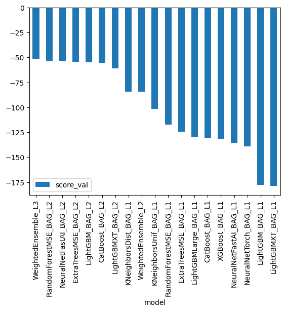

```python
predictor.leaderboard(silent=True).plot(kind='bar', x='model', y='score_val')
```

### Create predictions from test dataset

```python
predictions = predictor.predict(test)
predictions.head()
```

```
0    24.683168
1    43.330383
2    47.735603
3    49.336689
4    51.955627
Name: count, dtype: float32
```

#### NOTE: Kaggle will reject the submission if we don't set everything to be > 0.

```python
# Describe the `predictions` series to see if there are any negative values
predictions[predictions < 0].head()
```

```
Series([], Name: count, dtype: float32)
```

```python
# How many negative values do we have?
predictions[predictions < 0].shape
```

```
(0,)
```

```python
# Set them to zero
predictions[predictions < 0] = 0

# round count predictions to the nearest integer
predictions = predictions.apply(round)
```

### Set predictions to submission dataframe, save, and submit

```python
submission["count"] = predictions
submission.to_csv("submission.csv", index=False)

submission.head()
```

|  | datetime | count |
| --- | --- | --- |
| 0 | 2011-01-20 00:00:00 | 25 |
| 1 | 2011-01-20 01:00:00 | 43 |
| 2 | 2011-01-20 02:00:00 | 48 |
| 3 | 2011-01-20 03:00:00 | 49 |
| 4 | 2011-01-20 04:00:00 | 52 |

```python
!kaggle competitions submit -c bike-sharing-demand -f submission.csv -m "first raw submission"
```

```
Successfully submitted to Bike Sharing Demand
```

#### View submission via the command line or in the web browser under the competition's page - `My Submissions`

```python
!kaggle competitions submissions -c bike-sharing-demand | tail -n +1 | head -n 6
```

[output not shown]

## Step 4: Exploratory Data Analysis and Creating an additional feature

- Any additional feature will do, but a great suggestion would be to separate out the datetime into hour, day, or month parts.

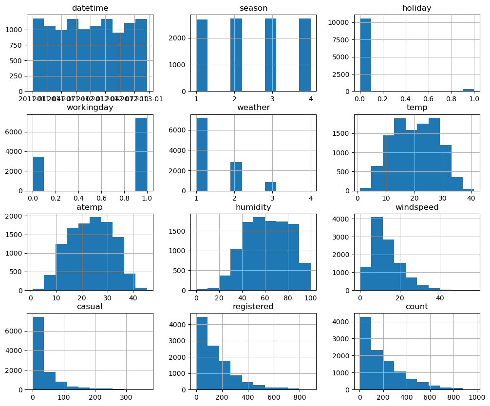

```python
# Create a histogram of all features to show the distribution of each one relative to the data. This is part of the exploritory data analysis
train.hist(figsize=(12, 10));
```

```python
# create a new feature
train['year'] = train['datetime'].dt.year
train['month'] = train['datetime'].dt.month
train['weekday'] = train['datetime'].dt.weekday
train['day'] = train['datetime'].dt.day
train['hour'] = train['datetime'].dt.hour

test['year'] = test['datetime'].dt.year
test['month'] = test['datetime'].dt.month
test['weekday'] = test['datetime'].dt.weekday
test['day'] = test['datetime'].dt.day
test['hour'] = test['datetime'].dt.hour
```

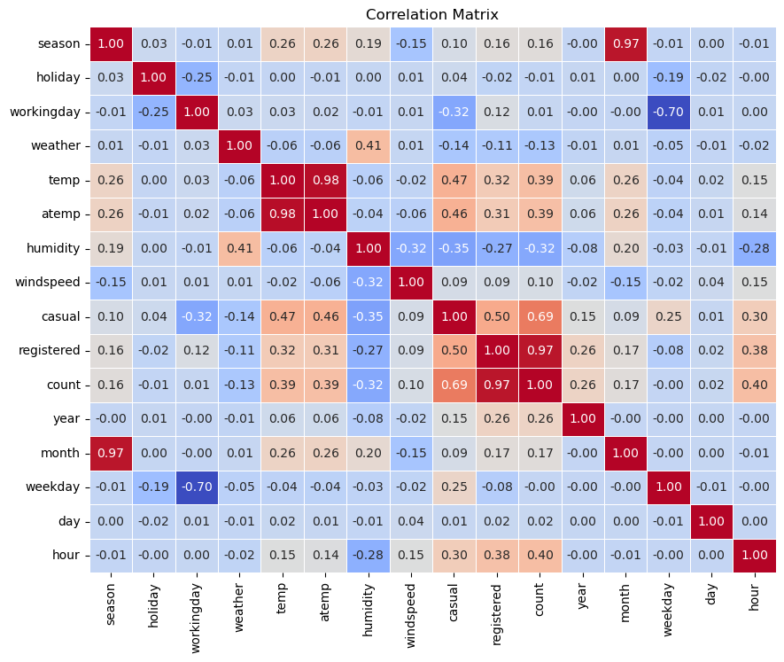

```python
import seaborn as sns
import matplotlib.pyplot as plt

plt.figure(figsize=(10, 8))
sns.heatmap(train.corr(numeric_only=True),
            annot=True,
            cmap="coolwarm",
            fmt=".2f",
            linewidths=0.5,
            cbar=False)
plt.title("Correlation Matrix")
plt.show()
```

## Make category types for these so models know they are not just numbers

- AutoGluon originally sees these as ints, but in reality they are int representations of a category.
- Setting the dtype to category will classify these as categories in AutoGluon.

```python
train["season"] = train["season"].astype('category')
train["weather"] = train["weather"].astype('category')

test["season"] = test["season"].astype('category')
test["weather"] = test["weather"].astype('category')
```

```python
# View are new feature
train.head()
```

|  | datetime | season | holiday | workingday | weather | temp | atemp | humidity | windspeed | casual | registered | count | year | month | weekday | day | hour |
| --- | --- | --- | --- | --- | --- | --- | --- | --- | --- | --- | --- | --- | --- | --- | --- | --- | --- |
| 0 | 2011-01-01 00:00:00 | 1 | 0 | 0 | 1 | 9.84 | 14.395 | 81 | 0.0 | 3 | 13 | 16 | 2011 | 1 | 5 | 1 | 0 |
| 1 | 2011-01-01 01:00:00 | 1 | 0 | 0 | 1 | 9.02 | 13.635 | 80 | 0.0 | 8 | 32 | 40 | 2011 | 1 | 5 | 1 | 1 |
| 2 | 2011-01-01 02:00:00 | 1 | 0 | 0 | 1 | 9.02 | 13.635 | 80 | 0.0 | 5 | 27 | 32 | 2011 | 1 | 5 | 1 | 2 |
| 3 | 2011-01-01 03:00:00 | 1 | 0 | 0 | 1 | 9.84 | 14.395 | 75 | 0.0 | 3 | 10 | 13 | 2011 | 1 | 5 | 1 | 3 |
| 4 | 2011-01-01 04:00:00 | 1 | 0 | 0 | 1 | 9.84 | 14.395 | 75 | 0.0 | 0 | 1 | 1 | 2011 | 1 | 5 | 1 | 4 |

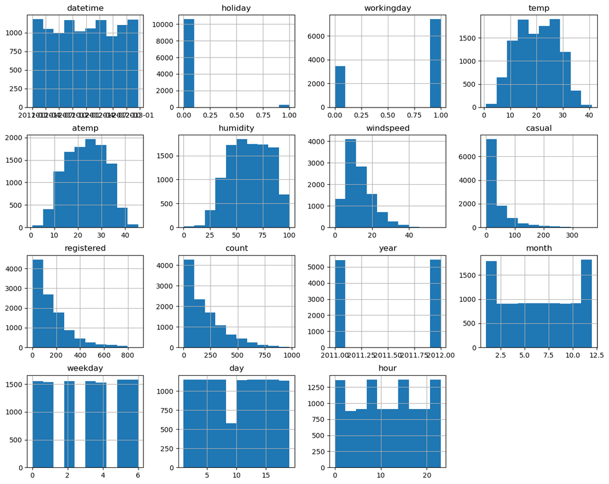

```python
# View histogram of all features again now with the hour feature
train.hist(figsize=(15, 12));
```

```python
train.corrwith(train['count'], numeric_only=True).abs().sort_values(ascending=False)
```

```
count         1.000000
registered    0.970948
casual        0.690414
hour          0.400601
temp          0.394454
atemp         0.389784
humidity      0.317371
year          0.260403
month         0.166862
windspeed     0.101369
day           0.019826
workingday    0.011594
holiday       0.005393
weekday       0.002283
dtype: float64
```

## Step 5: Rerun the model with the same settings as before, just with more features

```python
predictor_new_features = TabularPredictor(
    label='count',
    problem_type='regression',
    eval_metric='root_mean_squared_error'
).fit(
    train_data=train.drop(columns=['casual', 'registered']),
    time_limit=600,
    presets='best_quality'
)
```

```
No path specified. Models will be saved in: "AutogluonModels\ag-20230602_101239\"
Presets specified: ['best_quality']
Stack configuration (auto_stack=True): num_stack_levels=1, num_bag_folds=8, num_bag_sets=20
Beginning AutoGluon training ... Time limit = 600s
AutoGluon will save models to "AutogluonModels\ag-20230602_101239\"
AutoGluon Version:  0.7.0
Python Version:     3.9.16
Operating System:   Windows
Platform Machine:   AMD64
Platform Version:   10.0.22621
Train Data Rows:    10886
Train Data Columns: 14
Label Column: count
Preprocessing data ...
Using Feature Generators to preprocess the data ...
Fitting AutoMLPipelineFeatureGenerator...
	Available Memory:                    2309.52 MB
	Train Data (Original)  Memory Usage: 0.85 MB (0.0% of available memory)
	Inferring data type of each feature based on column values. Set feature_metadata_in to manually specify special dtypes of the features.
	Stage 1 Generators:
		Fitting AsTypeFeatureGenerator...
			Note: Converting 3 features to boolean dtype as they only contain 2 unique values.
	Stage 2 Generators:
		Fitting FillNaFeatureGenerator...
	Stage 3 Generators:
		Fitting IdentityFeatureGenerator...
		Fitting CategoryFeatureGenerator...
			Fitting CategoryMemoryMinimizeFeatureGenerator...
		Fitting DatetimeFeatureGenerator...
	Stage 4 Generators:
		Fitting DropUniqueFeatureGenerator...
	Types of features in original data (raw dtype, special dtypes):
		('category', []) : 2 | ['season', 'weather']
		('datetime', []) : 1 | ['datetime']
		('float', [])    : 3 | ['temp', 'atemp', 'windspeed']
		('int', [])      : 8 | ['holiday', 'workingday', 'humidity', 'year', 'month', ...]
	Types of features in processed data (raw dtype, special dtypes):
		('category', [])             : 2 | ['season', 'weather']
		('float', [])                : 3 | ['temp', 'atemp', 'windspeed']
		('int', [])                  : 5 | ['humidity', 'month', 'weekday', 'day', 'hour']
```

[output cut: 68 more lines]

```
	Fitting 8 child models (S1F1 - S1F8) | Fitting with ParallelLocalFoldFittingStrategy
	-30.6102	 = Validation score   (-root_mean_squared_error)
	88.12s	 = Training   runtime
	0.19s	 = Validation runtime
Fitting model: ExtraTreesMSE_BAG_L2 ... Training model for up to 7.94s of the 7.91s of remaining time.
	-31.5031	 = Validation score   (-root_mean_squared_error)
	6.72s	 = Training   runtime
	0.78s	 = Validation runtime
Completed 1/20 k-fold bagging repeats ...
Fitting model: WeightedEnsemble_L3 ... Training model for up to 360.0s of the -0.09s of remaining time.
	-30.2472	 = Validation score   (-root_mean_squared_error)
	0.37s	 = Training   runtime
	0.0s	 = Validation runtime
AutoGluon training complete, total runtime = 600.49s ... Best model: "WeightedEnsemble_L3"
TabularPredictor saved. To load, use: predictor = TabularPredictor.load("AutogluonModels\ag-20230602_101239\")
```

```python
predictor_new_features.fit_summary()
```

```
*** Summary of fit() ***
Estimated performance of each model:
                     model   score_val  pred_time_val    fit_time  pred_time_val_marginal  fit_time_marginal  stack_level  can_infer  fit_order
0      WeightedEnsemble_L3  -30.247197      38.917482  478.703732                0.000999           0.365009            3       True         15
1          LightGBM_BAG_L2  -30.583049      36.782053  356.286579                0.381178           5.793243            2       True         11
2          CatBoost_BAG_L2  -30.610206      36.591622  438.616652                0.190746          88.123316            2       True         13
3        LightGBMXT_BAG_L2  -31.098752      37.623197  361.814082                1.222321          11.320747            2       True         10
4     ExtraTreesMSE_BAG_L2  -31.503128      37.181027  357.212553                0.780152           6.719217            2       True         14
5   RandomForestMSE_BAG_L2  -31.537164      37.122238  373.101417                0.721362          22.608082            2       True         12
6      WeightedEnsemble_L2  -32.064782      34.574138  303.723857                0.002413           0.583527            2       True          9
7          CatBoost_BAG_L1  -33.754922       0.351721  248.511520                0.351721         248.511520            1       True          6
8          LightGBM_BAG_L1  -33.917339       3.509355   18.420474                3.509355          18.420474            1       True          4
9        LightGBMXT_BAG_L1  -34.296486      30.117106   28.094971               30.117106          28.094971            1       True          3
10    ExtraTreesMSE_BAG_L1  -37.811425       1.219185    5.319238                1.219185           5.319238            1       True          7
11  RandomForestMSE_BAG_L1  -38.377899       0.564666    8.064970                0.564666           8.064970            1       True          5
12  NeuralNetFastAI_BAG_L1  -48.488466       0.577738   41.982828                0.577738          41.982828            1       True          8
13   KNeighborsDist_BAG_L1  -84.146423       0.028877    0.048395                0.028877           0.048395            1       True          2
14   KNeighborsUnif_BAG_L1 -101.588176       0.032227    0.050939                0.032227           0.050939            1       True          1
Number of models trained: 15
Types of models trained:
{'StackerEnsembleModel_LGB', 'StackerEnsembleModel_XT', 'StackerEnsembleModel_RF', 'WeightedEnsembleModel', 'StackerEnsembleModel_CatBoost', 'StackerEnsembleModel_KNN', 'StackerEnsembleModel_NNFastAiTabular'}
Bagging used: True  (with 8 folds)
Multi-layer stack-ensembling used: True  (with 3 levels)
Feature Metadata (Processed):
(raw dtype, special dtypes):
('category', [])             : 2 | ['season', 'weather']
('float', [])                : 3 | ['temp', 'atemp', 'windspeed']
('int', [])                  : 5 | ['humidity', 'month', 'weekday', 'day', 'hour']
('int', ['bool'])            : 3 | ['holiday', 'workingday', 'year']
('int', ['datetime_as_int']) : 5 | ['datetime', 'datetime.year', 'datetime.month', 'datetime.day', 'datetime.dayofweek']
*** End of fit() summary ***
```

[output not shown]

[output cut: 139 more lines]

[output not shown]

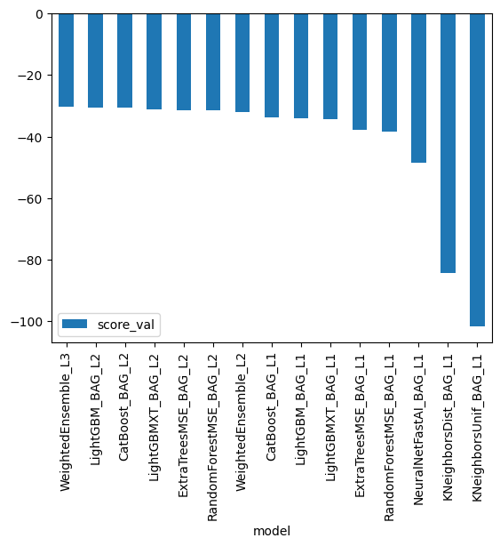

```python
predictor_new_features.leaderboard(silent=True).plot(kind='bar', x='model', y='score_val')
```

```python
predictions_new_fts = predictor_new_features.predict(test)
predictions_new_fts.head()
```

```
0    16.414841
1    11.117934
2    10.746465
3     9.114053
4     7.895049
Name: count, dtype: float32
```

```python
# Remember to set all negative values to zero
predictions_new_fts[predictions_new_fts < 0] = 0

predictions_new_fts = predictions_new_fts.apply(round)
```

```python
# Same submitting predictions
submission_new_features = pd.read_csv("data/sampleSubmission.csv", parse_dates=['datetime'])
submission_new_features["count"] = predictions_new_fts
submission_new_features.to_csv("submission_new_features.csv", index=False)

submission_new_features.head()
```

|  | datetime | count |
| --- | --- | --- |
| 0 | 2011-01-20 00:00:00 | 16 |
| 1 | 2011-01-20 01:00:00 | 11 |
| 2 | 2011-01-20 02:00:00 | 11 |
| 3 | 2011-01-20 03:00:00 | 9 |
| 4 | 2011-01-20 04:00:00 | 8 |

```python
!kaggle competitions submit -c bike-sharing-demand -f submission_new_features.csv -m "new features"
```

```
Successfully submitted to Bike Sharing Demand
```

```python
!kaggle competitions submissions -c bike-sharing-demand | tail -n +1 | head -n 6
```

```
fileName                     date                 description                        status    publicScore  privateScore
---------------------------  -------------------  ---------------------------------  --------  -----------  ------------
submission_new_features.csv  2023-06-02 10:35:50  new features                       pending
submission.csv               2023-06-02 10:34:26  first raw submission               complete  1.72744      1.72744
submission_new_hpo.csv       2023-06-01 15:43:04  new features with hyperparameters  complete  0.72564      0.72564
submission_new_features.csv  2023-06-01 15:41:57  new features                       complete  0.68410      0.68410
```

## Step 6: Hyper parameter optimization

- There are many options for hyper parameter optimization.
- Options are to change the AutoGluon higher level parameters or the individual model hyperparameters.
- The hyperparameters of the models themselves that are in AutoGluon. Those need the `hyperparameter` and `hyperparameter_tune_kwargs` arguments.

```python
import autogluon.core as ag

nn_options = {
    'num_epochs': 10,
    'learning_rate': ag.space.Real(1e-4, 1e-2, default=5e-4, log=True),
    'activation': ag.space.Categorical('relu', 'softrelu', 'tanh'),
    'dropout_prob': ag.space.Real(0.0, 0.5, default=0.1)
}

gbm_options = {
    'num_boost_round': 100,
    'num_leaves': ag.space.Int(lower=26, upper=66, default=36)
}

hyperparameters = {
    'GBM': gbm_options,
    'NN_TORCH': nn_options
}

hyperparameter_tune_kwargs = {
    'num_trials': 5,
    'scheduler' : 'local',
    'searcher': 'auto'
}

predictor_new_hpo = TabularPredictor(
    label='count',
    problem_type='regression',
    eval_metric='root_mean_squared_error'
).fit(
    train_data=train.drop(columns=['casual', 'registered']),
    time_limit=600,
    presets='best_quality',
    hyperparameters=hyperparameters,
    hyperparameter_tune_kwargs=hyperparameter_tune_kwargs
)
```

```
Fitted model: NeuralNetTorch_BAG_L2\3a5bf7c4 ...
	-38.0882	 = Validation score   (-root_mean_squared_error)
	37.63s	 = Training   runtime
	0.0s	 = Validation runtime
Fitted model: NeuralNetTorch_BAG_L2\10433226 ...
	-40.2975	 = Validation score   (-root_mean_squared_error)
	37.39s	 = Training   runtime
	0.0s	 = Validation runtime
Fitted model: NeuralNetTorch_BAG_L2\2d6997e0 ...
	-38.8181	 = Validation score   (-root_mean_squared_error)
	42.61s	 = Training   runtime
	0.0s	 = Validation runtime
Completed 1/20 k-fold bagging repeats ...
Fitting model: WeightedEnsemble_L3 ... Training model for up to 360.0s of the 74.66s of remaining time.
	-36.2159	 = Validation score   (-root_mean_squared_error)
	0.74s	 = Training   runtime
	0.0s	 = Validation runtime
AutoGluon training complete, total runtime = 526.14s ... Best model: "WeightedEnsemble_L3"
TabularPredictor saved. To load, use: predictor = TabularPredictor.load("AutogluonModels\ag-20230602_102303\")
```

```python
predictor_new_hpo.fit_summary()
```

```
*** Summary of fit() ***
Estimated performance of each model:
                             model   score_val  pred_time_val    fit_time  pred_time_val_marginal  fit_time_marginal  stack_level  can_infer  fit_order
0              WeightedEnsemble_L3  -36.215948       0.004032  365.634001                0.001000           0.742690            3       True         19
1               LightGBM_BAG_L2\T2  -36.428137       0.002026  270.899910                0.000000          19.381034            2       True         12
2               LightGBM_BAG_L2\T3  -36.772295       0.002026  270.490462                0.000000          18.971585            2       True         13
3               LightGBM_BAG_L2\T1  -36.819044       0.002026  269.659332                0.000000          18.140455            2       True         11
4               LightGBM_BAG_L2\T5  -37.370628       0.002026  275.460821                0.000000          23.941945            2       True         15
5              WeightedEnsemble_L2  -38.037104       0.003018   33.412545                0.002004           0.783048            2       True         10
6   NeuralNetTorch_BAG_L2\3a5bf7c4  -38.088175       0.002026  289.148424                0.000000          37.629548            2       True         16
7               LightGBM_BAG_L1\T3  -38.387471       0.000000   16.407597                0.000000          16.407597            1       True          3
8   NeuralNetTorch_BAG_L2\2d6997e0  -38.818138       0.002026  294.124144                0.000000          42.605268            2       True         18
9               LightGBM_BAG_L1\T2  -38.957554       0.001014   16.221900                0.001014          16.221900            1       True          2
10              LightGBM_BAG_L1\T1  -40.255449       0.000000   15.635433                0.000000          15.635433            1       True          1
11  NeuralNetTorch_BAG_L2\10433226  -40.297508       0.003032  288.909144                0.001006          37.390267            2       True         17
12              LightGBM_BAG_L1\T5  -43.339902       0.000000   16.133162                0.000000          16.133162            1       True          5
13  NeuralNetTorch_BAG_L1\e9e9dc3b  -74.606877       0.000000   70.450033                0.000000          70.450033            1       True          9
14  NeuralNetTorch_BAG_L1\e25b8a87  -96.931288       0.000000   29.715890                0.000000          29.715890            1       True          6
15              LightGBM_BAG_L2\T4 -102.921048       0.002026  270.181311                0.000000          18.662434            2       True         14
16              LightGBM_BAG_L1\T4 -120.841251       0.000000   15.499977                0.000000          15.499977            1       True          4
17  NeuralNetTorch_BAG_L1\ba803f81 -129.706254       0.001012   37.878722                0.001012          37.878722            1       True          7
18  NeuralNetTorch_BAG_L1\0c7693c5 -141.995127       0.000000   33.576162                0.000000          33.576162            1       True          8
Number of models trained: 19
Types of models trained:
{'StackerEnsembleModel_LGB', 'StackerEnsembleModel_TabularNeuralNetTorch', 'WeightedEnsembleModel'}
Bagging used: True  (with 8 folds)
Multi-layer stack-ensembling used: True  (with 3 levels)
Feature Metadata (Processed):
(raw dtype, special dtypes):
('category', [])             : 2 | ['season', 'weather']
('float', [])                : 3 | ['temp', 'atemp', 'windspeed']
('int', [])                  : 5 | ['humidity', 'month', 'weekday', 'day', 'hour']
('int', ['bool'])            : 3 | ['holiday', 'workingday', 'year']
('int', ['datetime_as_int']) : 5 | ['datetime', 'datetime.year', 'datetime.month', 'datetime.day', 'datetime.dayofweek']
*** End of fit() summary ***
```

[output not shown]

[output cut: 181 more lines]

[output not shown]

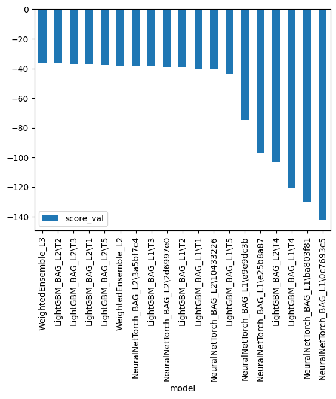

```python
predictor_new_hpo.leaderboard(silent=True).plot(kind='bar', x='model', y='score_val')
```

```python
predictions_hpo = predictor_new_hpo.predict(test)
predictions_hpo.head()
```

[output not shown]

[output cut: 137 more lines]

[output not shown]

```
0    12.559397
1     5.959979
2     5.548164
3     5.459671
4     5.465734
Name: count, dtype: float32
```

```python
# Remember to set all negative values to zero
predictions_hpo[predictions_hpo < 0] = 0

predictions_hpo = predictions_hpo.apply(round)
```

```python
submission_new_hpo = pd.read_csv("data/sampleSubmission.csv", parse_dates=['datetime'])
# Same submitting predictions
submission_new_hpo["count"] = predictions_hpo
submission_new_hpo.to_csv("submission_new_hpo.csv", index=False)

submission_new_hpo.head()
```

|  | datetime | count |
| --- | --- | --- |
| 0 | 2011-01-20 00:00:00 | 13 |
| 1 | 2011-01-20 01:00:00 | 6 |
| 2 | 2011-01-20 02:00:00 | 6 |
| 3 | 2011-01-20 03:00:00 | 5 |
| 4 | 2011-01-20 04:00:00 | 5 |

```python
!kaggle competitions submit -c bike-sharing-demand -f submission_new_hpo.csv -m "new features with hyperparameters"
```

```
Successfully submitted to Bike Sharing Demand
```

```python
!kaggle competitions submissions -c bike-sharing-demand | tail -n +1 | head -n 6
```

```
fileName                     date                 description                        status    publicScore  privateScore
---------------------------  -------------------  ---------------------------------  --------  -----------  ------------
submission_new_hpo.csv       2023-06-02 10:36:12  new features with hyperparameters  complete  0.46579      0.46579
submission_new_features.csv  2023-06-02 10:35:50  new features                       complete  0.67260      0.67260
submission.csv               2023-06-02 10:34:26  first raw submission               complete  1.72744      1.72744
submission_new_hpo.csv       2023-06-01 15:43:04  new features with hyperparameters  complete  0.72564      0.72564
```